# Lab 12 - Smoking during pregnancy

Simulation based inference

Max Asmar

## Introduction

In 2004, the state of North Carolina released a large data set containing information on births recorded in this state. This data set is useful to researchers studying the relation between habits and practices of expectant mothers and the birth of their children. We will work with a random sample of observations from this data set.

In this lab, you’ll use simulation-based inference methods to conduct hypothesis tests and construct confidence intervals. This approach uses bootstrapping to create null distributions and sampling distributions without relying on mathematical formulas.

**Estimated time:** 90-120 minutes

## Learning Goals

By the end of this lab, you will be able to:

- Conduct hypothesis tests using simulation-based methods
- Construct confidence intervals using bootstrapping
- Interpret p-values in context
- Interpret confidence intervals in context
- Verify conditions for inference
- Compare means and proportions between groups
- Visualize null distributions and sampling distributions

## Prerequisites

Before you begin, make sure you have:

- ✅ Completed Labs 01-11
- ✅ Watched lectures on hypothesis testing and confidence intervals
- ✅ Understand null and alternative hypotheses
- ✅ Understand p-values and significance levels
- ✅ Forked the lab-instructions repository

# Getting Started

Navigate to your forked `lab-instructions` repository in JupyterHub, open the `Lab12` folder, and open the R Markdown document `lab-12.Rmd`.

## Verify Your Setup

Before proceeding:

Step 1. Open `lab-12.Rmd` in RStudio

Step 2. Check that the Git pane shows YOUR username (not the course organization)

Step 3. Click **Knit** to make sure the document compiles

## Warm Up

**Step 1:** Update the YAML, changing the author name to your name.

**Step 2:** Knit the document.

**Step 3:** Commit your changes with message “Updated author name”.

#Completed warm up

**Step 4:** Push to GitHub and verify the changes are visible in your repo.

🧶 ✅ ⬆️ **Knit, commit with message “Completed warm up”, and push your changes.**

## Packages

We’ll use the **tidyverse** package for much of the data wrangling and visualisation, the **tidymodels** package for inference, and the data lives in the **openintro** package. These packages are already installed for you. You can load them by running the following in your Console:

```r
library(tidyverse)
library(tidymodels)
library(openintro)
```

## Data

The data can be found in the **openintro** package, and it’s called `ncbirths`. Since the dataset is distributed with the package, we don’t need to load it separately; it becomes available to us when we load the package. You can find out more about the dataset by inspecting its documentation, which you can access by running `?ncbirths` in the Console or using the Help menu in RStudio to search for `ncbirths`. You can also find this information [here](https://www.openintro.org/data/index.php?data=ncbirths).

**✓ Checkpoint:** Run `glimpse(ncbirths)` in your Console to verify the data loaded correctly.

Ran in console.

```r
    glimpse(ncbirths)
```

```
## Rows: 1,000
## Columns: 13
## $ fage           <int> NA, NA, 19, 21, NA, NA, 18, 17, NA, 20, 30, NA, NA, NA,…
## $ mage           <int> 13, 14, 15, 15, 15, 15, 15, 15, 16, 16, 16, 16, 16, 16,…
## $ mature         <fct> younger mom, younger mom, younger mom, younger mom, you…
## $ weeks          <int> 39, 42, 37, 41, 39, 38, 37, 35, 38, 37, 45, 42, 40, 38,…
## $ premie         <fct> full term, full term, full term, full term, full term, …
## $ visits         <int> 10, 15, 11, 6, 9, 19, 12, 5, 9, 13, 9, 8, 4, 12, 15, 7,…
## $ marital        <fct> not married, not married, not married, not married, not…
## $ gained         <int> 38, 20, 38, 34, 27, 22, 76, 15, NA, 52, 28, 34, 12, 30,…
## $ weight         <dbl> 7.63, 7.88, 6.63, 8.00, 6.38, 5.38, 8.44, 4.69, 8.81, 6…
## $ lowbirthweight <fct> not low, not low, not low, not low, not low, low, not l…
## $ gender         <fct> male, male, female, male, female, male, male, male, mal…
## $ habit          <fct> nonsmoker, nonsmoker, nonsmoker, nonsmoker, nonsmoker, …
## $ whitemom       <fct> not white, not white, white, white, not white, not whit…
```

## Set a Seed!

In this lab we’ll be generating random samples through bootstrapping. The last thing you want is those samples to change every time you knit your document. So, you should **set a seed**.

**What is a seed?** A seed tells R where to start its random number generation. Using the same seed ensures you get the same “random” results each time you knit.

```r
# Set your seed here - use any number you like
set.seed(1234)
```

**Choose any number** - just make sure you use the same seed throughout the entire lab.

# Exercises

## Exercise 1

What are the cases in this data set? How many cases are there in our sample?

**Explore the data:**

```r
glimpse(ncbirths)
```

```
## Rows: 1,000
## Columns: 13
## $ fage           <int> NA, NA, 19, 21, NA, NA, 18, 17, NA, 20, 30, NA, NA, NA,…
## $ mage           <int> 13, 14, 15, 15, 15, 15, 15, 15, 16, 16, 16, 16, 16, 16,…
## $ mature         <fct> younger mom, younger mom, younger mom, younger mom, you…
## $ weeks          <int> 39, 42, 37, 41, 39, 38, 37, 35, 38, 37, 45, 42, 40, 38,…
## $ premie         <fct> full term, full term, full term, full term, full term, …
## $ visits         <int> 10, 15, 11, 6, 9, 19, 12, 5, 9, 13, 9, 8, 4, 12, 15, 7,…
## $ marital        <fct> not married, not married, not married, not married, not…
## $ gained         <int> 38, 20, 38, 34, 27, 22, 76, 15, NA, 52, 28, 34, 12, 30,…
## $ weight         <dbl> 7.63, 7.88, 6.63, 8.00, 6.38, 5.38, 8.44, 4.69, 8.81, 6…
## $ lowbirthweight <fct> not low, not low, not low, not low, not low, low, not l…
## $ gender         <fct> male, male, female, male, female, male, male, male, mal…
## $ habit          <fct> nonsmoker, nonsmoker, nonsmoker, nonsmoker, nonsmoker, …
## $ whitemom       <fct> not white, not white, white, white, not white, not whit…
```

**Your answers:**

**What are the cases?** Each case represents information regarding births in North Carolina. Some variables include the mothers age, fathers age, gender of the baby, and if the mother was a smoker or nonsmoker.

**How many cases are there?** Use inline code to report the number.

There are 1000 cases in our sample.

## Exercise 2

The first step in the analysis of a new dataset is getting acquainted with the data. Make summaries of the variables in your dataset, determine which variables are categorical and which are numerical. For numerical variables, are there outliers? If you aren’t sure or want to take a closer look at the data, make a graph.

**Create summary statistics:**

```r
# Remember to change eval=FALSE to eval=TRUE!

# For numerical variables
ncbirths %>%
  select(where(is.numeric)) %>%
  summary()
```

```
##       fage            mage        weeks           visits         gained
##  Min.   :14.00   Min.   :13   Min.   :20.00   Min.   : 0.0   Min.   : 0.00
##  1st Qu.:25.00   1st Qu.:22   1st Qu.:37.00   1st Qu.:10.0   1st Qu.:20.00
##  Median :30.00   Median :27   Median :39.00   Median :12.0   Median :30.00
##  Mean   :30.26   Mean   :27   Mean   :38.33   Mean   :12.1   Mean   :30.33
##  3rd Qu.:35.00   3rd Qu.:32   3rd Qu.:40.00   3rd Qu.:15.0   3rd Qu.:38.00
##  Max.   :55.00   Max.   :50   Max.   :45.00   Max.   :30.0   Max.   :85.00
##  NA's   :171                  NA's   :2       NA's   :9      NA's   :27
##      weight
##  Min.   : 1.000
##  1st Qu.: 6.380
##  Median : 7.310
##  Mean   : 7.101
##  3rd Qu.: 8.060
##  Max.   :11.750
##
```

```r
# For categorical variables
ncbirths %>%
  select(where(is.factor)) %>%
  summary()
```

```
##          mature          premie           marital    lowbirthweight
##  mature mom :133   full term:846   not married:386   low    :111
##  younger mom:867   premie   :152   married    :613   not low:889
##                    NA's     :  2   NA's       :  1
##     gender          habit          whitemom
##  female:503   nonsmoker:873   not white:284
##  male  :497   smoker   :126   white    :714
##               NA's     :  1   NA's     :  2
```

**List the variables:**’

The variables are fage, mage, weeks, visits, gained, weight, mature, premie, marital, lowbirthweight, gender, habit, and whitemom.

**Categorical variables:**

The categorical variables are mature, premie, marital, lowbirthweight, gender, habit, and whitemom

**Numerical variables:**

The numerical variables are fage, mage, weeks, visits, gained, and weight.

**Check for outliers in key variables:**

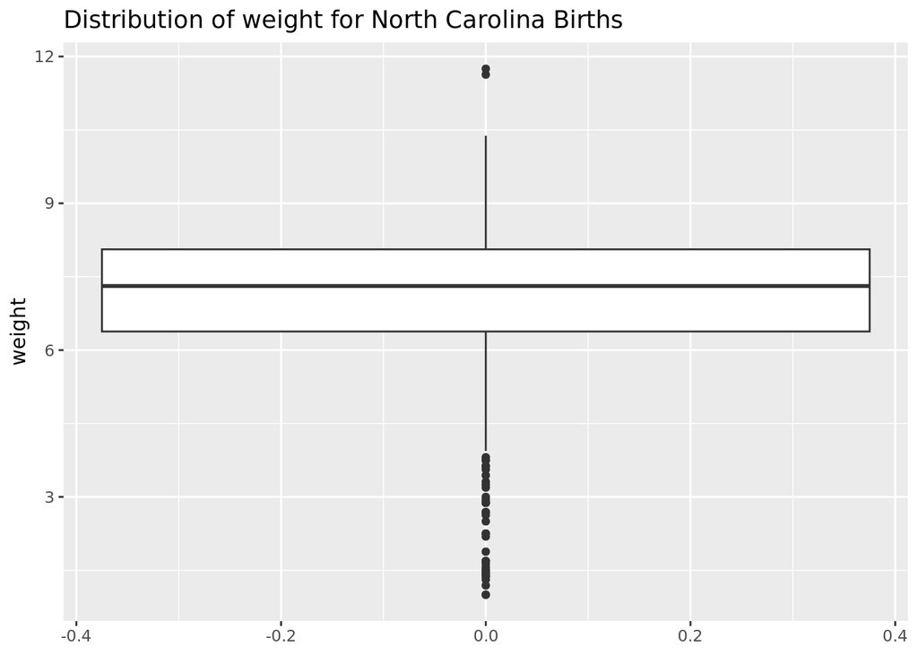

```r
# Remember to change eval=FALSE to eval=TRUE!

# Boxplot for weight
ggplot(data = ncbirths, aes(y = weight)) +
  geom_boxplot() +
  labs(title = "Distribution of weight for North Carolina Births")
```

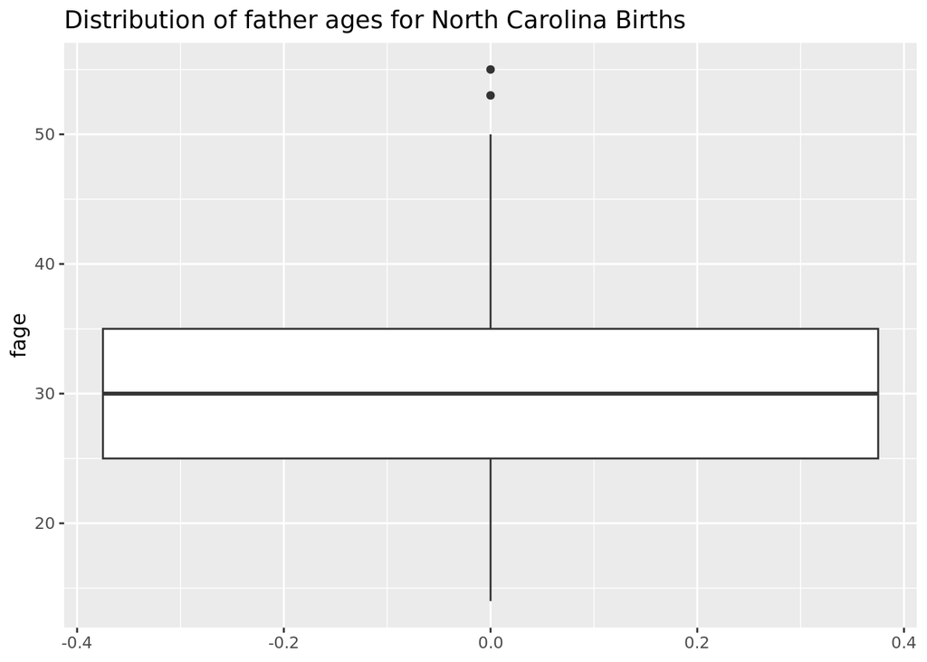

```r
# Boxplot for other numerical variables as needed

ggplot(data = ncbirths, aes(y = fage)) +
  geom_boxplot() +
  labs(title = "Distribution of father ages for North Carolina Births")
```

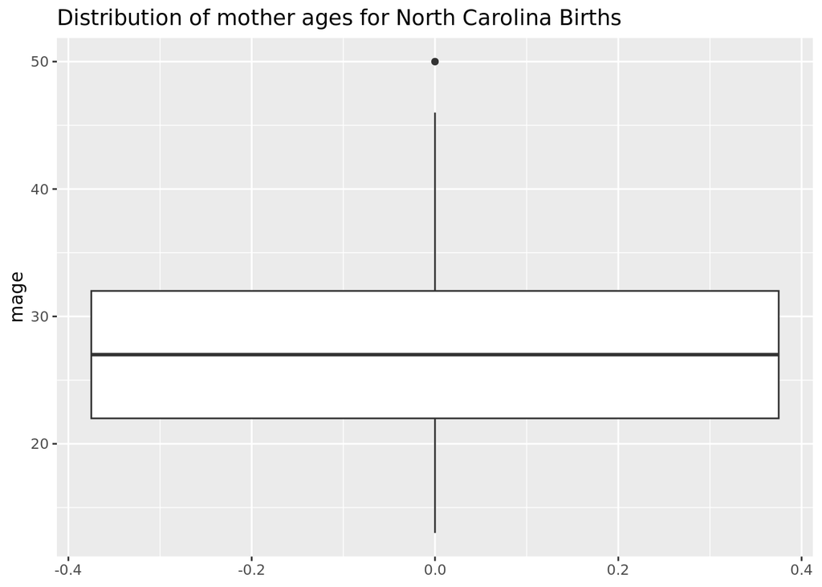

```r
ggplot(data = ncbirths, aes(y = mage)) +
  geom_boxplot() +
  labs(title = "Distribution of mother ages for North Carolina Births")
```

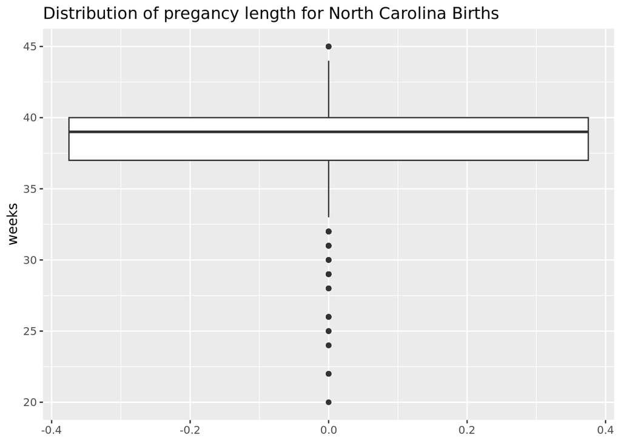

```r
ggplot(data = ncbirths, aes(y = weeks)) +
  geom_boxplot() +
  labs(title = "Distribution of pregancy length for North Carolina Births")
```

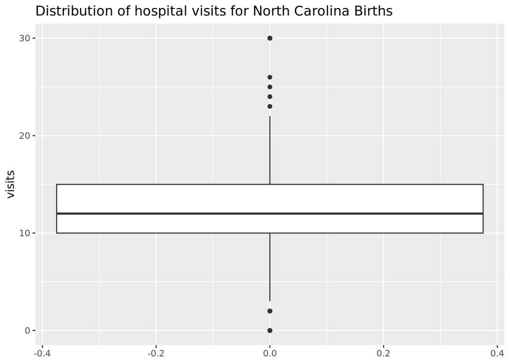

```r
ggplot(data = ncbirths, aes(y = visits)) +
  geom_boxplot() +
  labs(title = "Distribution of hospital visits for North Carolina Births")
```

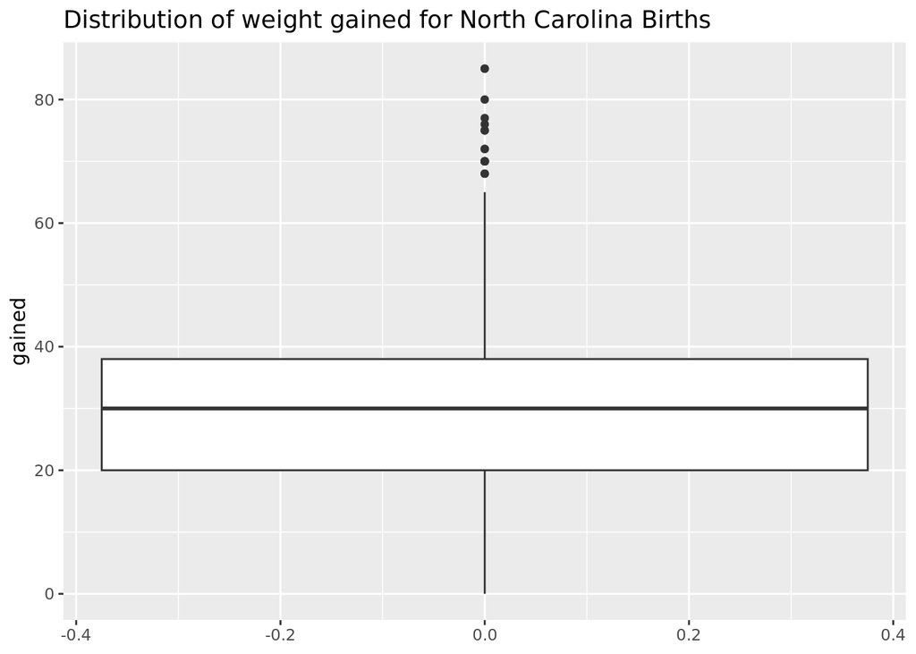

```r
ggplot(data = ncbirths, aes(y = gained)) +
  geom_boxplot() +
  labs(title = "Distribution of weight gained for North Carolina Births")
```

**Are there outliers?**

Yes, there are outliers for all of the numerical variables. I can identify this because there are isolated dots on all of the boxplots for the numerical variables.

🧶 ✅ ⬆️ **Knit, commit with message “Completed Exercises 1-2”, and push your changes.**

## Part 1: Baby Weights

A 1995 study suggests that average weight of Caucasian babies born in the US is 3,369 grams (7.43 pounds). In this dataset we only have information on mother’s race, so we will make the simplifying assumption that babies of Caucasian mothers are also Caucasian, i.e. `whitemom = "white"`.

Wen, Shi Wu, Michael S. Kramer, and Robert H. Usher. “Comparison of birth weight distributions between Chinese and Caucasian infants.” American Journal of Epidemiology 141.12 (1995): 1177-1187.

We want to evaluate whether the average weight of Caucasian babies has changed since 1995.

**Our hypotheses:**

- **Null hypothesis:** There is no change since 1995: $H_0: \mu = 7.43$ pounds
- **Alternative hypothesis:** There is some change since 1995: $H_A: \mu \ne 7.43$ pounds

Note that this is a **two-sided test** because we’re testing for any change (could be higher or lower).

## Exercise 3

Create a filtered data frame called `ncbirths_white` that contains data only from white mothers. Then, calculate the mean of the weights of their babies.

```r
# Remember to change eval=FALSE to eval=TRUE!
ncbirths_white <- ncbirths %>%
  filter(whitemom == "white")

# Calculate mean weight
mean_weight_white <- ncbirths_white %>%
  summarise(mean_weight = mean(weight)) %>%
  pull(mean_weight)

mean_weight_white
```

```
## [1] 7.250462
```

**The observed mean weight is:** 7.25 pounds

**How does this compare to 7.43 pounds?**

The observed mean weight of 7.25 pounds is less than 7.43 pounds.

## Exercise 4

Are the conditions necessary for conducting simulation-based inference satisfied? Explain your reasoning.

**Conditions for simulation-based inference:**

part (a) **Independence:** Observations must be independent

part (b) **Sample size:** Need a reasonably large sample

part (c) **Random sampling:** Sample should be random or representative

**Check each condition:**

**Independence:**

Yes, the observations are independent because births are generally independent as the birth of one baby does not affect the birth of another one in the same period, generally speaking.

**Sample size:** How many white mothers are in the dataset?

```r
# Remember to change eval=FALSE to eval=TRUE!
nrow(ncbirths_white)
```

```
## [1] 714
```

There are 714 observations. Is this large enough?

Yes, this is large enough because we have around 700 observations which should be large enough to see clear patterns in the data, if any.

**Random sampling:**

Yes, according to the Help section of the ncbirths dataset, the observations are a random sample of births in North Carolina.

**Conclusion: Are conditions satisfied?**

## Yes, all 3 conditions are satisfied. This means we can reasonably use simulation based inference.

## Exercise 5

Run the appropriate hypothesis test, visualize the null distribution, calculate the p-value, and interpret the results in context of the data and the hypothesis test.

**How this test works:**

We’ll use bootstrapping to create a null distribution:

Step 1. Take bootstrap samples from our data

Step 2. Calculate the mean for each bootstrap sample

Step 3. Shift the distribution to center at the null value (7.43)

Step 4. See how extreme our observed mean is

**Run the hypothesis test:**

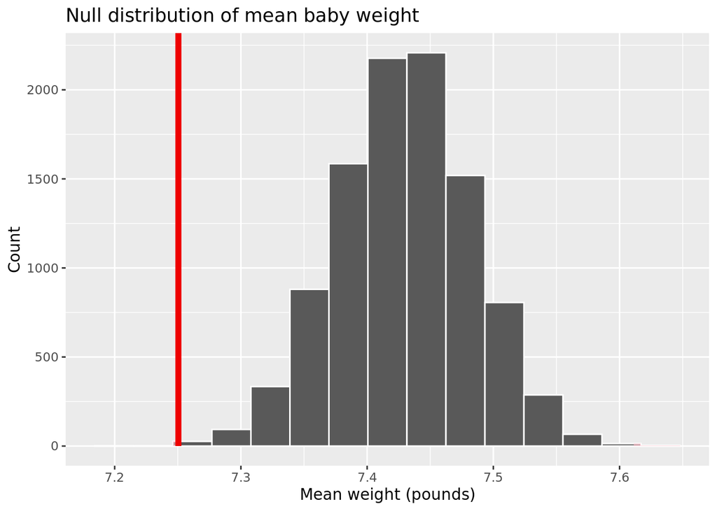

```r
# Remember to change eval=FALSE to eval=TRUE!

# Calculate observed statistic (difference from null)
obs_stat <- ncbirths_white %>%
  specify(response = weight) %>%
  calculate(stat = "mean")

# Generate null distribution
null_dist <- ncbirths_white %>%
  specify(response = weight) %>%
  hypothesize(null = "point", mu = 7.43) %>%  # Null value in pounds
  generate(reps = 10000, type = "bootstrap") %>%
  calculate(stat = "mean")

# Visualize null distribution
visualize(null_dist) +
  shade_p_value(obs_stat = obs_stat, direction = "two-sided") +
  labs(
    title = "Null distribution of mean baby weight",
    x = "Mean weight (pounds)",
    y = "Count"
  )
```

```r
# Calculate p-value
null_dist %>%
  get_p_value(obs_stat = obs_stat, direction = "two-sided")
```

```
## # A tibble: 1 × 1
##   p_value
##     <dbl>
## 1  0.0008
```

**Hints:** - `mu = 7.43` for the null value - `direction = "two-sided"` for a two-sided test

**The p-value is:** 0.0008

**Interpretation:**

At a significance level of 0.05, we reject the null hypothesis because the p-value is 0.0008, which is less than the significance level. In other words, because the p value is below the significance level, we know that there has been significant change in the average weight of White babies from 1995 to 2004.

In context:

There has been significant change in the average weight of White babies from 1995 to 2004, according to the data and p values.

🧶 ✅ ⬆️ **Knit, commit with message “Completed Exercises 3-5”, and push your changes.**

## Part 2: Baby Weight vs. Smoking

Consider the possible relationship between a mother’s smoking habit and the weight of her baby. Plotting the data is a useful first step because it helps us quickly visualize trends, identify strong associations, and develop research questions.

## Exercise 6

Make side-by-side boxplots displaying the relationship between `habit` and `weight`. What does the plot highlight about the relationship between these two variables?

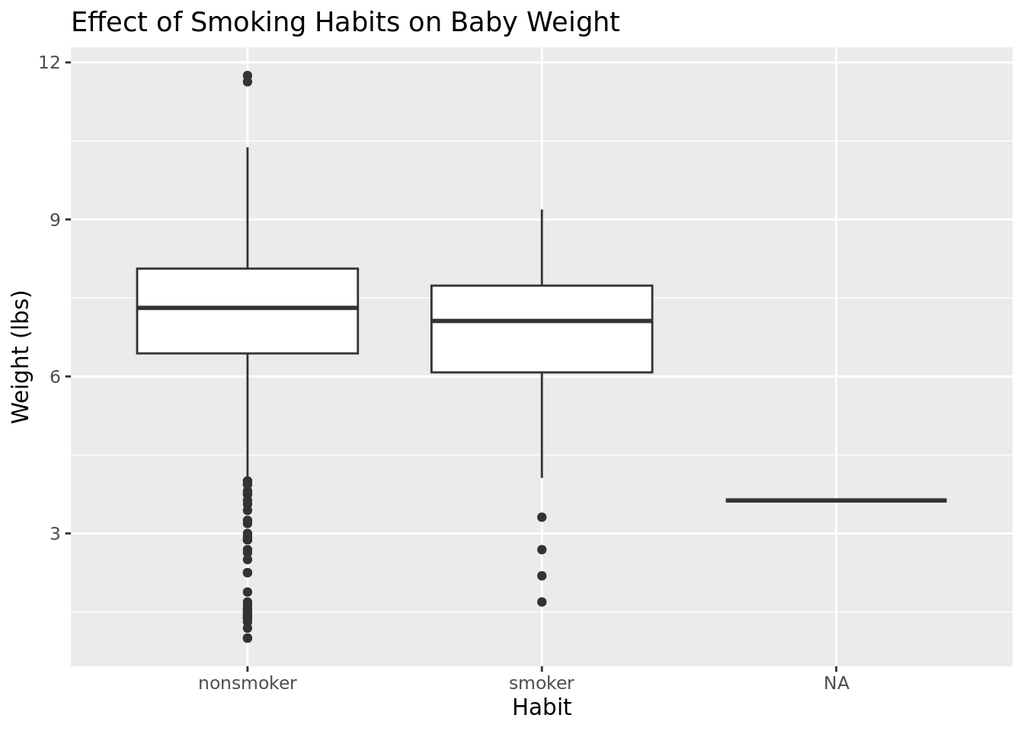

```r
# Remember to change eval=FALSE to eval=TRUE!
ggplot(data = ncbirths, aes(x = habit, y = weight)) +
  geom_boxplot() +
  labs(
    title = "Effect of Smoking Habits on Baby Weight",
    x = "Habit",
    y = "Weight (lbs)"
  )
```

**What does the plot show about the relationship?**

The plot shows that there is a slighly negative relationship between maternal smoking and median baby weight.

**Which group has higher median weight?**

Nonsmokers have babies with slightly higher median weights.

## Exercise 7

Before moving forward, save a version of the dataset omitting observations where there are NAs for `habit`. You can call this version `ncbirths_habitgiven`.

```r
# Remember to change eval=FALSE to eval=TRUE!
ncbirths_habitgiven <- ncbirths %>%
  filter(!is.na(habit))

# Check how many observations we have
nrow(ncbirths_habitgiven)
```

```
## [1] 999
```

**How many observations remain after removing NAs?** 999 observations.

The box plots show how the medians of the two distributions compare, but we can also compare the means of the distributions using the following to first group the data by the `habit` variable, and then calculate the mean `weight` in these groups:

```r
# Remember to change eval=FALSE to eval=TRUE after completing the code above
ncbirths_habitgiven %>%
  group_by(habit) %>%
  summarise(mean_weight = mean(weight))
```

```
## # A tibble: 2 × 2
##   habit     mean_weight
##   <fct>           <dbl>
## 1 nonsmoker        7.14
## 2 smoker           6.83
```

**Observed difference in means:**

Mean weight for nonsmokers: 7.14 pounds Mean weight for smokers: 6.83 pounds Difference: 0.31 pounds

**There is an observed difference, but is this difference statistically significant?**

🧶 ✅ ⬆️ **Knit, commit with message “Completed Exercises 6-7”, and push your changes.**

## Exercise 8

Write the hypotheses for testing if the average weights of babies born to smoking and non-smoking mothers are different.

**Null hypothesis (H₀):**

The average weights of babies born to smoking and non-smoking mothers are the same.

**Alternative hypothesis (Hₐ):**

The average weights of babies born to smoking and non-smoking mothers are different.

**Hint:** Since we’re testing for “different” (not specifically higher or lower), this is a two-sided test.

## Exercise 9

Are the conditions necessary for conducting simulation-based inference satisfied? Explain your reasoning.

**Check conditions:**

**Independence:**

Yes, every birth is mainly independent of another birth, with few exceptions such as having twins.

**Sample size in each group:**

```r
# Remember to change eval=FALSE to eval=TRUE!
ncbirths_habitgiven %>%
  count(habit)
```

```
## # A tibble: 2 × 2
##   habit         n
##   <fct>     <int>
## 1 nonsmoker   873
## 2 smoker      126
```

Nonsmokers: 873 observations Smokers: 126 observations

**Are these large enough?**

Yes, this number of observations are large enough for simulation-based inference.

**Random sampling:**

Yes, the study/dataset uses a random sample of births in North Carolina.

**Conclusion:**

Yes, it is appropriate to use simulation-based inference to answer our hypotheses.

## Exercise 10

Run the appropriate hypothesis test, calculate the p-value, and interpret the results in context of the data and the hypothesis test.

```r
# Remember to change eval=FALSE to eval=TRUE!

# Calculate observed statistic
obs_diff <- ncbirths_habitgiven %>%
  specify(weight ~ habit) %>%
  calculate(stat = "diff in means", order = c("nonsmoker", "smoker"))

obs_diff
```

```
## Response: weight (numeric)
## Explanatory: habit (factor)
## # A tibble: 1 × 1
##    stat
##   <dbl>
## 1 0.316
```

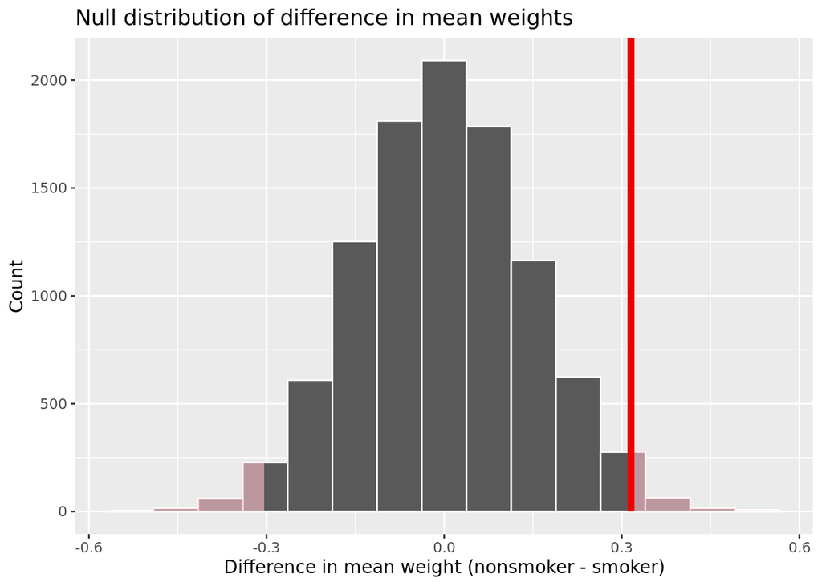

```r
# Generate null distribution
null_dist_habit <- ncbirths_habitgiven %>%
  specify(weight ~ habit) %>%
  hypothesize(null = "independence") %>%
  generate(reps = 10000, type = "permute") %>%
  calculate(stat = "diff in means", order = c("nonsmoker", "smoker"))

# Visualize
visualize(null_dist_habit) +
  shade_p_value(obs_stat = obs_diff, direction = "two-sided") +
  labs(
    title = "Null distribution of difference in mean weights",
    x = "Difference in mean weight (nonsmoker - smoker)",
    y = "Count"
  )
```

```r
# Calculate p-value
null_dist_habit %>%
  get_p_value(obs_stat = obs_diff, direction = "two-sided")
```

```
## # A tibble: 1 × 1
##   p_value
##     <dbl>
## 1  0.0306
```

**The observed difference is:** 0.316 pounds

**The p-value is:** 0.0306

**Interpretation:**

We reject the null hypothesis because the p value of 0.0306 is less than the significance level of 0.05. In other words, the average weights of babies born to smoking and non-smoking mothers in North Carolina are different, on average by 0.316 pounds.

## Exercise 11

Construct a 95% confidence interval for the difference between the average weights of babies born to smoking and non-smoking mothers.

```r
# Remember to change eval=FALSE to eval=TRUE!

# Generate bootstrap distribution
boot_dist_habit <- ncbirths_habitgiven %>%
  specify(weight ~ habit) %>%
  generate(reps = 10000, type = "bootstrap") %>%
  calculate(stat = "diff in means", order = c("nonsmoker", "smoker"))

# Get confidence interval
ci <- boot_dist_habit %>%
  get_confidence_interval(level = 0.95, type = "percentile")

ci
```

```
## # A tibble: 1 × 2
##   lower_ci upper_ci
##      <dbl>    <dbl>
## 1   0.0617    0.582
```

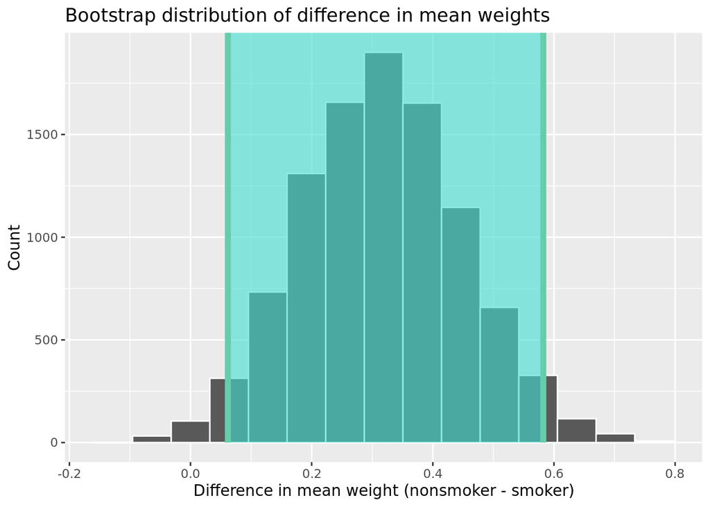

```r
# Visualize
visualize(boot_dist_habit) +
  shade_confidence_interval(endpoints = ci) +
  labs(
    title = "Bootstrap distribution of difference in mean weights",
    x = "Difference in mean weight (nonsmoker - smoker)",
    y = "Count"
  )
```

**The 95% confidence interval is:** (0.0617, 0.582)

**Interpretation in context:**

We are 95% confident that the difference between the average weights of babies born to smoking and non-smoking mothers is between 0.0617 and 0.582 pounds.

🧶 ✅ ⬆️ **Knit, commit with message “Completed Exercises 8-11”, and push your changes.**

## Part 3: Baby Weight vs. Mother’s Age

In this portion of the analysis we focus on two variables. The first one is `maturemom`.

## Exercise 12

First, a non-inference task: Determine the age cutoff for younger and mature mothers. Use a method of your choice, and explain how your method works.

**Explore the maturemom variable:**

```r
# Remember to change eval=FALSE to eval=TRUE!

# Look at the relationship between age and maturemom
ncbirths %>%
  group_by(mature) %>%
  summarise(
    min_age = min(mage, na.rm = TRUE),
    max_age = max(mage, na.rm = TRUE)
  )
```

```
## # A tibble: 2 × 3
##   mature      min_age max_age
##   <fct>         <int>   <int>
## 1 mature mom       35      50
## 2 younger mom      13      34
```

**The age cutoff is:** 35 years

**Explanation of method:**

I determined this by finding the age range for both mature moms and younger moms. First I group the data by maternal maturity status, and then I find summary statistics of the minimum and maximum age for each group. I then identify the minimum age for mature mom (35) and the maximum age for younger mom (34)

The other variable of interest is `lowbirthweight`.

## Exercise 13

Conduct a hypothesis test evaluating whether the proportion of low birth weight babies is higher for mature mothers. State the hypotheses, verify the conditions, run the test and calculate the p-value, and state your conclusion in context of the research question. Use α = 0.05. If you find a significant difference, construct a confidence interval, at the equivalent level to the hypothesis test, for the difference between the proportions of low birth weight babies between mature and younger mothers, and interpret this interval in context of the data.

**State the hypotheses:**

**H₀:** The proportion of low birth weight babies is the same for mature and younger mothers.

**Hₐ:** The proportion of low birth weight babies is greater for mature mothers than younger mothers.

**Note:** This is a **one-sided test** because we’re testing if mature mothers have a *higher* proportion.

**Verify conditions:**

**Independence:**

Yes, there is mostly independence because each birth does not affect the other births in most cases, however there are few exceptions such as twins.

**Sample size:**

```r
# Remember to change eval=FALSE to eval=TRUE!
ncbirths %>%
  filter(!is.na(mature), !is.na(lowbirthweight)) %>%
  count(mature)
```

```
## # A tibble: 2 × 2
##   mature          n
##   <fct>       <int>
## 1 mature mom    133
## 2 younger mom   867
```

The sample uses data from 133 mature moms and 867 younger moms.

**Are conditions satisfied?**

Yes, because there is random sampling, independence, and a large sample size.

**Calculate observed proportions:**

```r
# Remember to change eval=FALSE to eval=TRUE!
ncbirths %>%
  filter(!is.na(mature), !is.na(lowbirthweight)) %>%
  group_by(mature) %>%
  summarise(prop_low = mean(lowbirthweight == "low"))
```

```
## # A tibble: 2 × 2
##   mature      prop_low
##   <fct>          <dbl>
## 1 mature mom     0.135
## 2 younger mom    0.107
```

**Observed proportions:**

Younger mothers: 0.107 Mature mothers: 0.135

**Run the hypothesis test:**

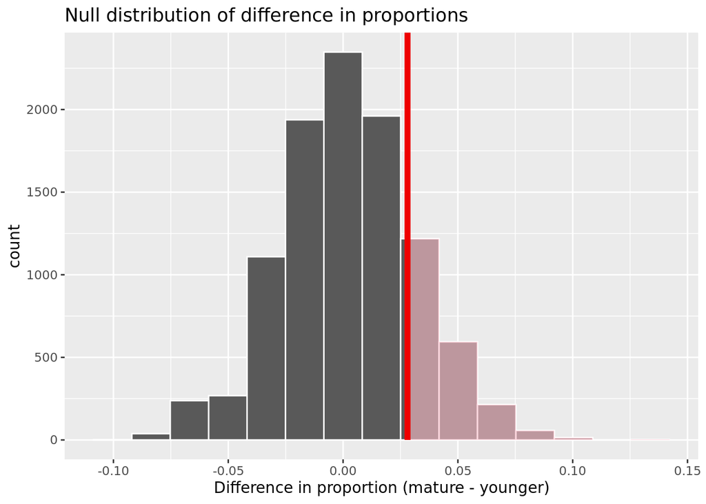

```r
# Remember to change eval=FALSE to eval=TRUE!

# Create filtered dataset
ncbirths_mature <- ncbirths %>%
  filter(!is.na(mature), !is.na(lowbirthweight))

# Calculate observed statistic
obs_diff_prop <- ncbirths_mature %>%
  specify(lowbirthweight ~ mature, success = "low") %>%
  calculate(stat = "diff in props", order = c("mature mom", "younger mom"))

# Generate null distribution
null_dist_mature <- ncbirths_mature %>%
  specify(lowbirthweight ~ mature, success = "low") %>%
  hypothesize(null = "independence") %>%
  generate(reps = 10000, type = "permute") %>%
  calculate(stat = "diff in props", order = c("mature mom", "younger mom"))

# Visualize
visualize(null_dist_mature) +
  shade_p_value(obs_stat = obs_diff_prop, direction = "greater") +
  labs(
    title = "Null distribution of difference in proportions",
    x = "Difference in proportion (mature - younger)"
  )
```

```r
# Calculate p-value
p_value <- null_dist_mature %>%
  get_p_value(obs_stat = obs_diff_prop, direction = "greater")

p_value
```

```
## # A tibble: 1 × 1
##   p_value
##     <dbl>
## 1   0.210
```

**Hint:** `direction = "greater"` for a one-sided test

**The p-value is:** 0.210

**Conclusion:**

Since the p value of 0.210 is greater than the significance level of 0.05, there is inadequate evidence to support the hypothesis that the proportion of low birth weight babies is greater for mature mothers than younger mothers.

**If significant, construct a 95% confidence interval:**

```r
# Remember to change eval=FALSE to eval=TRUE!
# Only run if you found a significant difference

boot_dist_mature <- ncbirths_mature %>%
  specify(lowbirthweight ~ mature, success = "low") %>%
  generate(reps = 10000, type = "bootstrap") %>%
  calculate(stat = "diff in props", order = c("mature mom", "younger mom"))

ci_mature <- boot_dist_mature %>%
  get_confidence_interval(level = 0.95, type = "percentile")

ci_mature
```

We do not need to run a confidence interval because the p value of 0.210 was greater than the significance level of 0.05.

🧶 ✅ ⬆️ **Knit, commit with message “Completed Exercises 12-13”, and push your changes.**

## Common Errors and Troubleshooting

**Simulation-based inference errors:**

- **Error: “could not find function ‘specify’”** → Load tidymodels: `library(tidymodels)`
- **Different results each time** → Make sure you set a seed at the beginning
- **Error: “success level not found”** → Check spelling of your success level (e.g., “low” vs “Low”)

**Hypothesis test errors:**

- **Wrong direction** → Two-sided: “two-sided”, One-sided: “greater” or “less”
- **Order matters** → The order in `calculate()` affects the sign of your statistic
- **Null hypothesis confusion** → “point” for means, “independence” for differences

**Confidence interval errors:**

- **CI doesn’t match test** → Use same confidence level as significance level (95% CI with α=0.05)
- **Can’t interpret CI** → Remember: it’s a range of plausible values for the parameter

**Bootstrap errors:**

- **Very long run time** → 10,000 reps is standard, but you can use 1,000 for testing
- **Results change** → Set a seed!

**General issues:**

- **Code chunk not running** → Change `eval=FALSE` to `eval=TRUE`
- **NA values causing problems** → Filter them out with `filter(!is.na(variable))`

## Reflection

**Key concepts from this lab:**

- **Hypothesis testing:** We test whether observed differences are due to chance
- **P-values:** Probability of seeing our result (or more extreme) if null hypothesis is true
- **Confidence intervals:** Range of plausible values for a parameter
- **Bootstrapping:** Resampling technique that creates distributions without formulas
- **Independence vs. point nulls:** Different null hypotheses for different questions

**Important reminders:**

- Always set a seed for reproducibility
- Check conditions before running tests
- Interpret results in context (not just “reject” or “fail to reject”)
- P-value < α means statistically significant
- Confidence intervals give more information than hypothesis tests

**To submit to Canvas:**

Step 1. In RStudio, click the **Knit** dropdown menu (next to the Knit button)

Step 2. Select **Knit to tufte_handout** to generate a PDF

Step 3. Download the PDF file from the Files pane

Step 4. Upload the PDF to Canvas

**✓ Final Checkpoint:** Visit your GitHub repo one more time to confirm all your work is there. We will grade what we see in your repo on GitHub!